# stat_QC_labels()

Kenith Grey

2017-03-20

# Description

Write QC line lables to ggplot QC Charts. Useful if you want to see the value of the center line and QC limits. see method argument for methods supported.

# Usage

```
stat_QC_labels(mapping = NULL, data = NULL, geom = "label",
position = "identity", na.rm = FALSE, show.legend = NA,
inherit.aes = TRUE, n = NULL, digits = 1, method = "xBar.rBar",
color.qc_limits = "red", color.qc_center = "black", text.size = 3,      ...)
```

# Specialized Arguments for Stat_QC_labels()

**n**: number, for

- Studentized Charts, used for custom or hypothetical subgroup size.
- np Charts, used to specify a fixed area of opportunity.

**digits** integer, indicating the number of decimal places

**method** : string, calling the following methods:

- **Individuals Charts**: mR, XmR,
- **Attribute Charts**: c, np, p, u,
- **Studentized Charts**: xBar.rBar, xBar.rMedian, xBar.sBar, xMedian.rBar, xMedian.rMedian
- **Dispersion Charts**: rBar, rMedian, sBar.

**color.qc_limits** : color, used to colorize the plot’s upper and lower mR control limits.

**color.qc_center** : color, used to colorize the plot’s center line.

**text.size** : number, size of the text label

**…**: other arguments passed on to layer. These are often aesthetics, used to set an aesthetic to a fixed value, like color = “red” or size = 3. They may also be parameters to the paired geom/stat.

# Examples

```r
# Setup Data --------------------------------------------------------------
set.seed(5555)
Process1 <- data.frame(processID = as.factor(rep(1,100)),
                       metric_value = rnorm(100,0,1),
                       subgroup_sample=rep(1:20, each=5),
                       Process_run_id = 1:100)
```

### Base Plot

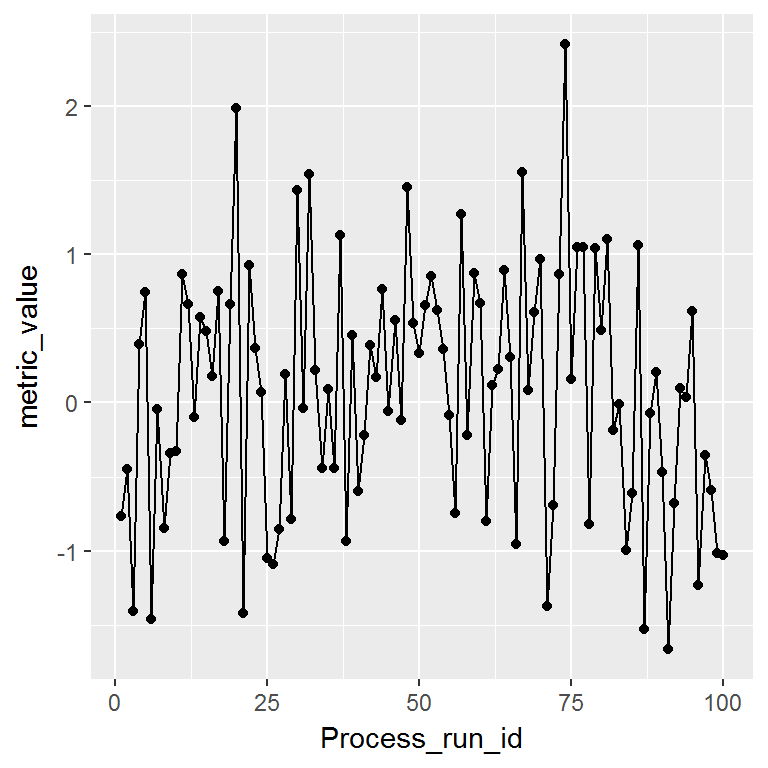

```r
INDV <- ggplot(Process1, aes(x=Process_run_id, y = metric_value)) +
       geom_point() + geom_line()
INDV
```

### XmR Default Overlay with XmR Labels

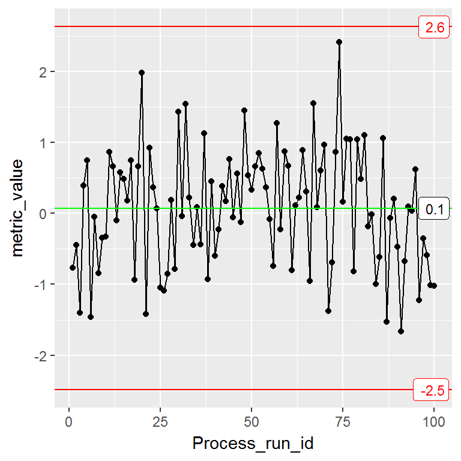

```r
INDV + stat_QC(method="XmR") +
  stat_QC_labels(method="XmR")
```

### Change Center-Label Color

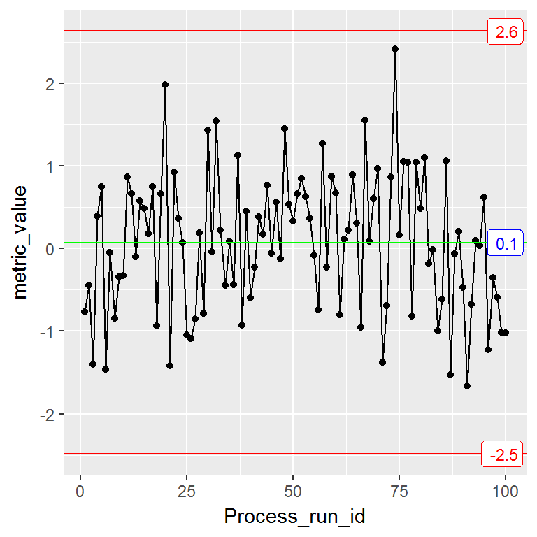

```r
INDV + stat_QC(method="XmR") +
  stat_QC_labels(method="XmR", color.qc_center = "blue")
```

### Change Limit-Label Color

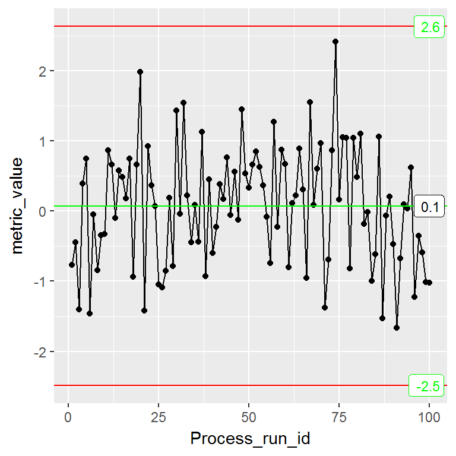

```r
INDV + stat_QC(method="XmR") +
  stat_QC_labels(method="XmR", color.qc_limits = "green")
```

### Change Label Size

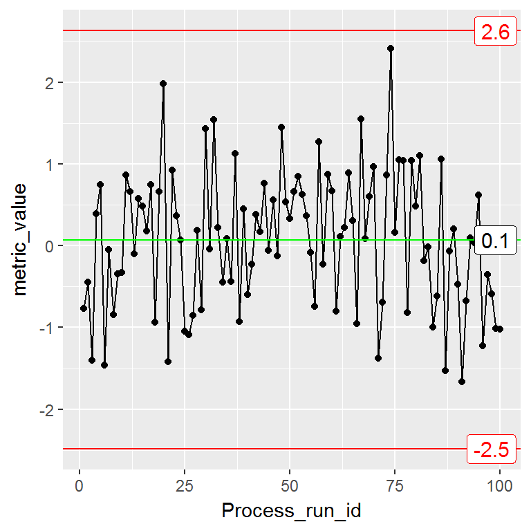

```r
INDV + stat_QC(method="XmR") +
  stat_QC_labels(method="XmR", text.size = 4)
```